User Manual

# User Manual

[figure not shown]

Version: VECTO 2.2 / VectoCore 3.0.2 / VectoCmd 3.0.2

VECTO is a tool for the calculation of energy consumption and CO<sub>2</sub> emissions of vehicles. It models the components of a heavy-duty vehicle and simulates a virtual drive on a route. The goal is to provide a standardized way of calculating the energy consumption (fuel consumption) and corresponding CO<sub>2</sub> emissions.

This User Manual consists of 4 Parts:

- **Graphical User Interface:**

  Here graphical user interface of VECTO with all windows and configuration possibilities is described.
- **Calculation Modes:**

  The calculation modes of VECTO are described here (Declaration, Engineering, …).
- **Simulation Models:**

  This chapter describes the used component models and formulas which are implemented in the software.
- **Input and Output:**

  The input and output file formats are described in this chapter.

This user manual describes both, version 2.2 and verson 3.0.x of Vecto. Vecto 3.x is a complete rewrite of Vecto 2.2 that uses the same models and input data and also produces the same output. However, in some parts version 3.x differs from version 2.2. The according paragraphs are highlighted accordingly.

# User Interface

When VECTO starts the Main Form is loaded. Closing this form will close VECTO even if other dialogs are still open.

- Main Form
- Settings
- Job Editor
- Aux Dialog
- Vehicle Editor
- Engine Editor
- Gearbox Editor
- Graph Window

## Main Form

[figure not shown]

### Description

The Main Form is loaded when starting VECTO. Closing this form will close VECTO even if other dialogs are still open. In this form all global settings can be controlled and all other application dialogs can be opened.

In order to start a simulation the Calculation Mode must be set and at least one Job File (.vecto) must added to the Job List. After clicking START all checked files in the Job List will be calculated. From the user interface you can either run the simulation using Vecto 2.2 or Vecto 3.x by clicking the according START button on the left side of the window.

The Main Form includes three tabs as described below:

- Job Files Tab
- Driving Cycles Tab (only if Batch Mode is enabled)
- Options Tab

### Job Files List

Job files (.vecto) listed here will be used for calculation. Unchecked files will be ignored! Doubleclick entries to edit job files with the VECTO Editor.

**All**

(Un-)Check all files in Job List. Only checked files are calculated when clicking START.

*Add files to Job List*

*Remove selected files from List*

*Move selected files up or down in list*

#### List Options

- **Save/Load List**
  - Save or load Job List to text file
- **Load Autosave-List**
  - The Autosave-List is saved automatically on application exit and calculation start
- **Clear List**
  - Remove all files from Job List
- **Remove Paths**
  - Remove paths, i.e. only file names remain using the Working Directory as source path.

### *START Button*

Start VECTO in the selected mode (see Options).

### Driving Cycles Tab

**Driving Cycle List**

The Driving Cycles List is only used in Batch Mode. The same controls are used as in the Job Files List.

### Options Tab

In this tab the global calculation settings can be changed.

**Declaration Mode**

Select either Declaration Mode or Engineering Mode

**Write modal results**

Toggle output of modal results (.vmod files). Summary files (.vsum, .vres) are always created.

**Batch Mode**

If Declaration Mode is disabled VECTO can be run in Batch Mode.

**Cycle Distance Correction**

Toggle Cycle Distance Correction. Always ON in Declaration Mode. Cycle Distance Correction monitors the driven distance in each time step and, if necessary, adds or removes time steps in order to keep the original distance given in the driving cycle.

- If **enabled** the vehicle drives the same **distance** as given in the driving cycle
- If *disabled* the vehicle travels the same **time** as given in the driving cycle (Note that distance-based cycles (see here) are always converted to time-based cycles internally)

**Use gears/rpm’s form driving cycle**

If activated VECTO will use gear and/or engine speed defintions included in the driving cycle (see here).

**Shutdown system after last job**

If activated VECTO will shutdown the system after the last job was completed. (Can be aborted during 100 seconds before shutdown.)

**Output Path (BATCH Mode only)**

Select target directory for result files (.vmod, .vres, .vsum)

**Create Subdirectories for modal results (BATCH Mode only)**

If activated a subdirectory for each job file will be created inside **Output Path** for modal output.

### Controls

**New Job File**

Create a new .vecto file using the VECTO Editor

**Open existing Job or Input File**

Open an existing input file (Job, Engine, etc.)

*Tools*

- **Job, Vehicle, Engine, Gearbox Editor**
  - Opens the respective Editor
- **Graph**
  - Open a new Graph Window
- **Open Log**
  - Opens the Log File in the system’s default text editor
- **Settings**
  - Opens the Settings dialog.

*Help*

- **User Manual**
  - Opens this User Manual
- **Release Notes**
  - Open the Release Notes (pdf)
- **Report Bug via CITnet / JIRA**
  - Open the CITnet/JIRA website for reporting bug
- **Create Activation File**
  - Create an Activation File used for Licensing
- **About VECTO**
  - Information about the software, license and support contact

**Message List**

All messages, warnings and errors are displayed here and written to the log file LOG.txt in the VECTO application folder. Depending on the colour the following message types are displayed:

- Status Messages
- Warnings
- Errors
- Links - click to open file/user manual/etc.

Note that the message log can be opened in the Tools menu with **Open Log**.

In addition to the log messages shown in the message list, Vecto 3 writes more elaborate messages in the subdirectory logs. If multiple simulations are run in parallel (e.g., in declartion mode a vehicle is simulated on different cycles with different loadings) a separate log-file is created for every simulation run.

**Statusbar**

Displays current status and progress of active simulations. When no simulation is executed the current mode is displayed (Standard, Batch or Declaration Mode).

## Settings

[figure not shown]

### Description

In the Settings dialog controls general application settings. The settings are saved in the settings.json file.

### Interface Settings

**Logfile Size Limit [MB]**

Whenever the Log File reaches this size it will be restarted. One backup is always stored as LOG_backup.txt. *Note:* this setting only affects the log-file written by the graphical user interface. The log-files written in the logs subdirectory are not limited by this setting!

**File Open Command**

This command will be used to open CSV Input Files like Driving Cycles (.vdri). See: [Run command](http://en.wikipedia.org/wiki/Run_command)  
**Name**: Name of the command as it will be shown in the menu when clicking the button.  
**Command**: The actual command.

*Example* *: If the command is* *excel* *and the file is* *C:\VECTO\cycle1.vdri* *then VECTO will run:* *excel “C:\VECTO\cycle1.vdri”*

### Calculation Settings

**Air Density [kg/m³]**

The Air Density is needed to calculate the air resistance together with the **Drag Coefficient** and the **Cross Sectional Area** (see Vehicle Editor).

**Fuel Density [kg/l]**

The Fuel Density is used to calculate the l/km results.

**CO<sub>2</sub> -to-Fuel Ratio[-]**

Mass ratio (kg<sub>CO2</sub> / kg<sub>FC</sub>) used to calculate CO<sub>2</sub> emissions.

### Controls

**Reset All Settings**

All values in the Settings dialog and Options Tab of the Main Form will be restored to default values.

*Save and close dialog*

*Close without saving*

## Job Editor

[figure not shown]

### Description

The job file (.vecto) includes all informations to run a VECTO calculation. It defines the vehicle and the driving cycle(s) to be used for calculation. In summary it defines:

- Filepath to the Vehicle File (.vveh) which defines the not-engine/gearbox-related vehicle parameters
- Filepath to the Engine File (.veng) which includes full load curve(s) and the fuel consumption map
- Filepath ot the Gearbox File (.vgbx) which defines gear ratios and transmission losses
- Auxiliaries
- Driver Assist parameters
- Driving Cycles (not used in Batch Mode)

### Relative File Paths

It is recommended to use relative filepaths. This way the Job File and all input files can be moved without having to update the paths. Example: “Vehicles\Vehicle1.vveh” points to the “Vehicles” subdirectory of the Job File’s directoy.

VECTO automatically uses relative paths if the input file (e.g. Vehicle File) is in the same directory as the Job File. (*Note:* The Job File must be saved before browsing for input files.)

### General Settings

**Engine Only Mode**

Enables Engine Only Mode (Engineering mode only). The following parameters are needed for this mode:

- Filepath to the Engine File (.veng)
- Driving Cycles including engine torque (or power) and engine speed

**Filepath to the Vehicle File (.vveh)**

Files can be created and edited using the Vehicle Editor.

**Filepath to the Engine File (.veng)**

Files can be created and edited using the Engine Editor.

**Filepath ot the Gearbox File(.vgbx)**

Files can be created and edited using the Gearbox Editor.

**Auxiliaries**

This list contains all auxiliaries used for calculation. The auxiliaries are configured using the Auxiliary Dialog. In Declaration Mode the set of auxiliaries and their power-demand is pre-defined, depending on the vehicle category and driving cycle. In Engineering Mode the set of auxiliaries can be freely defined. For each auxiliary an Auxiliary Input File (.vaux) must be provided and the driving cycle must include the corresponding supply power. **Double-click** entries to edit with the Auxiliary Dialog.

Add new Auxiliary

Remove the selected Auxiliary from the list

See Auxiliaries for details.

**Cycles**

List of cycles used for calculation. The .vdri format is described here. **Double-click** an entry to open the file (see File Open Command). **Click** selected items to edit file paths.

Add cycle (.vdri)

Remove the selected cycle from the list

### Driver Assist Tab

In this tab the driver assistance functions are enabled and parameterised.

**Engine Start/Stop**

See Engine Start/Stop for details.

**Overspeed / Eco-Roll**

See Overspeed / Eco-Roll for details.

**Look-Ahead Coasting**

See Look-Ahead Coasting for details.

**Acceleration Limiting**

See Acceleration Limiting for details.

### Chart Area

If a valid Vehicle File, Engine File and Gearbox File is loaded into the Editor the main vehicle parameters like HDV class and axle configuration are shown here. The plot shows the full load curve(s) and shift polygons. In Declaration Mode the **generic** shift polygons are shown, not the ones from the Gearbox File.

### Controls

**New Job File**

Create a new empty .vecto file

**Open existing Job File**

Open an existing .vecto file

*Save current Job File*

*Save Job File as…*

**Send current file to Job List in Main Form**

**Note:** The file will be sent to the Job List automatically when saved.

*Open Vehicle Editor*

*Open Engine Editor*

*Open Gearbox Editor*

*Browse for vehicle/engine/gearbox files*

**Save and close file**

File will be added to Job List in the Main Form.

*Cancel without saving*

## Auxiliary Dialog

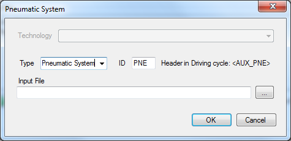

### Description

The Auxiliary Dialog is used to configure auxiliaries. In Declaration Mode the set of auxiliaries and their power demand is pre-defined. The user has to select for every auxiliary the technology from a given list. In Engineering Mode the set of auxiliaries can be specified by the user. Auxiliary efficieny is defined using an Auxiliary Input File (.vaux). See Auxiliaries for details on how the power demand for each auxiliary is calculated.

### Settings

**Technology**

List of available technology for the auxiliary type (declaration mode)

**Type**

String defining type of auxiliary. Click the arrow to load from a predefined list, however It is not required to use a type from the list.

**ID**

The ID string is required to link the auxiliary to the corresponding supply power definition in the driving cycle. The ID must contain characters and numbers only (A-Z, a-z, 0-9). The ID is not case sensitive (e.g. “ALT” will link to “Alt” or “alt”, etc.) *Example* *: Auxiliary “ALT” is linked to the column “<Aux_ALT>” in the driving cylce.* See Auxiliaries for details.

**Input File**

Path to the Auxiliary File (.vaux).

### Controls

*Save and close*

*Close without saving*

## Vehicle Editor

[figure not shown]

### Description

The Vehicle File (.vveh) defines the main vehicle/chassis parameters like axles including RRCs, air resistance and weight.

### Relative File Paths

It is recommended to use relative filepaths. This way the Job File and all input files can be moved without having to update the paths. Example: “Demo\RT1.vrlm” points to the “Demo” subdirectory of the Vehicle File’s directoy.

VECTO automatically uses relative paths if the input file (e.g. Retarder Losses File) is in the same directory as the Vehicle File. (*Note:* The Vehicle File must be saved before browsing for input files.)

### General vehicle parameters

**Vehicle Category**

Needed for Declaration Mode to identify the HDV Class.

**Axle Configuration**

Needed for Declaration Mode to identify the HDV Class.

**Gross Vehicle Mass Rating [t]**

Needed for Declaration Mode to identify the HDV Class.

**HDV Class**

Displays the automatically selected HDV Class depending on the settings above.

### Weight/Loading

These fields define the weight and loading of the vehicle. **Max. Loading** displays the maximum possible loading for the selected vehicle depending on curb weight and GVW values.

*Note:* *VECTO uses the sum of* *Curb Weight Vehicle, Curb Weight Extra Trailer/Body* *and* *Loading* *for calculation!*

### Air Resistance

The product of Drag Coefficient [-] and Cross Sectional Area [m²] (**c<sub>d</sub> x A**) and **Air Density** [kg/m³] (see Settings) together with the vehicle speed defines the Air Resistance. Note that the Air Drag depends on the chosen **Cross Wind Correction**.

### Axles/Wheels

For each axle the parameters **Relative axle load, RRC<sub>ISO</sub>** and **F<sub>zISO</sub>** have to be given in order to calculate the total Rolling Resistance Coefficient. Furthermore the **Wheels Inertia [kgm²]** has to be set per wheel for each axle. In Declaration Mode the inertia is computed based on the selected tyres and rims. The number of axles specified have to match the vehicle type (e.g., 2 axles for a 4x2 truck).

In Declaration mode only the axles of the truck have to be given. For the trailer predefined wheels and weight-shares are used.

In Engineering Mode all axles, for both truck and trailer, have to be given.

Use the and buttons to add or remove axles form the vehicle. Doubleclick entries to edit existing axle configurations.

**Dynamic Tyre Radius [mm]**

Effective (dynamic) wheel radius used to calculate engine speed. In Declaration Mode the radius calculated automatically using tyres/rims of the powered axle.

**Powered axle tyres/rims**

Needed for Declaration Mode to calculate the dynamic tyre radius.

### Retarder Losses

If a separate retarder is used in the vehicle a **Retarder Torque Loss Map** can be defined here to consider idling losses caused by the retarder.

- No retarder
- Included in Transmission Loss Maps: Use this if the Transmission Loss Maps already include retarder losses.
- Primary Retarder (before gearbox): The rpm ratio is relative to the engine speed
- Secondary Retarder (after gearbox): The rpm ratio is relative to the cardan shaft speed

Both, primary and secondary retarders, require an Retarder Torque Loss Input File (.vrlm).

### Cross Wind Correction Options

**Four different options are available:**

- No Correction: The specified CdxA value is used to compute the air drag, no cross-wind correction is applied
- Speed dependent (User-defined): The specified CdxA value is corrected depending on the vehicle’s speed.
- Speed dependent (Declaration Mode): A uniformly distributed cross-wind is assumed and used for correcting the air-drag depending on the vehicle’s speed
- Vair & Beta Input: Correction mode if the actual wind speed and wind angle relative to the vehicle have been measured.

In delcaration mode the ‘Speed dependent (Declaration Mode)’ cross-wind correction is used.

Depending on the chosen mode either a Speed Dependent Cross Wind Correction Input File (.vcdv) or a Vair & Beta Cross Wind Correction Input File (.vcdb) must be defined. For details see Cross Wind Correction.

### Controls

**New file**

Create a new empty .vveh file

**Open existing file**

Open an existing .vveh file

*Save current file*

*Save file as…*

**Send current file to the VECTO Editor**

**Note:** If the current file was opened via the VECTO Editor the file will be sent automatically when saved.

**Save and close file**

If necessary the file path in the VECTO Editor will be updated.

*Cancel without saving*

## Engine Editor

[figure not shown]

### Description

The Engine File (.veng) defines all engine-related parameters and input files like Fuel Consumption Map and Full Load Curve.

### Relative File Paths

It is recommended to use relative filepaths. This way the Job File and all input files can be moved without having to update the paths. Example: “Demo\FLD1.vfld” points to the “Demo” subdirectory of the Engine File’s directory.

VECTO automatically uses relative paths if the input file (e.g. FC Map) is in the same directory as the Engine File. *Note:* The Engine File must be saved before browsing for input files.)

### Main Engine Parameters

**Make and Model [text]**

Free text defining the engine model, type, etc.

**Idling Engine Speed [rpm]**

Low idle, applied in simulation for vehicle standstill in neutral gear position.

**Displacement [ccm]**

Used in Declaration Mode to calculate inertia.

**Inertia including Flywheel [kgm²]**

Inertia for rotating parts including engine flywheel. In Declaration Mode the inertia is calculated automatically depending on the engine’s displacement and also accounts for the clutch’s inertia.

### Full Load and Drag Curves

The Engine’s Full Load and Drag Curves (.vfld) limits the engine’s maximum torque and drag torque respectively The full-load curve must at least cover the engine-speed range from idling speed up to the speed where the power goes down to 70% of the maximum power. The input file (.vfld) file format is described here.

### Fuel Consumption Map

The Fuel Consumption Map is used to calculate the base FC value. See Fuel Consumption Calculation for details.

The input file (.vmap) file format is described here.

### WHTC Correction Factors

The WHTC Correction Factors are required in Declaration Mode for the WHTC FC Correction.

### Chart Area

The Chart Area shows the fuel consumption map and the selected full load curve.

### Controls

**New file**

Create a new empty .veng file

**Open existing file**

Open an existing .veng file

*Save current file*

*Save file as…*

**Send current file to the VECTO Editor**

**Note:** If the current file was opened via the VECTO Editor the file will be sent automatically when saved.

*Open file browser*.

*Open file* (see File Open Command).

**Save and close file**

If necessary the file path in the VECTO Editor will be updated.

*Cancel without saving*

## Gearbox Editor

[figure not shown]

### Description

The Gearbox File (.vgbx) defines alls gearbox-related input parameters like gear ratios and transmission loss maps. See Gear Shift Model for details.

### Relative File Paths

It is recommended to use relative filepaths. This way the Job File and all input files can be moved without having to update the paths.  
Example: “Gears\Gear1.vtlm” points to the “Gears” subdirectory of the Gearbox File’s directoy.

VECTO automatically uses relative paths if the input file (e.g. Shift Polygons File) is in the same directory as the Gearbox File. (The Gearbox File must be saved before browsing for input files.)

### Main Gearbox Parameters

**Make and Model**

Free text defining the gearbox model, type, etc.

**Transmission Type**

Depending on the transmission type some options below are not available. The following types are available:

- **MT**: Manual Transmission
- **AMT**: Automated Manual Transmission
- **AT**: Automatic Transmission
- **Custom**

Note: The types AT and Custom are not available in Declaration Mode.

**Inertia [kgm²]**

Rotational inertia of the gearbox (constant for all gears). (Engineering mode only)

**Traction Interruption [s]**

Interruption during gear shift event. (Engineering mode only)

### Gears

Use the and buttons to add or remove gears from the vehicle. Doubleclick entries to edit existing gears.

- Gear **“A”** defines the ratio of the axle transmission / differential.
- **“TC”** (AT only) defines which gears are using the torque converter (lock-up clutch open).
- **“Ratio”** defines the ratio between the output speed and input speed for the current gear. Must be greater than 0.
- **“Loss Map or Efficiency”** allows to define either a constant efficiency value or a loss map (.vtlm). Note: in Vecto 3 it is mandatory to specify a loss map for every gear!
- **“Shift polygons”** defines the Shift Polygons InputFile (.vgbs) for each gear. Not required in Declaration Mode. See GearShift Model for details.
- **“Full Load Curves”** defines the Full Load Curve for (.vfld) each gear. It is used for torque limiting in the current gear. Note: in Declaration mode the generic shift polygons are computed from the engine’s full-load curve. If the maximum torque is limited by the gearbox, the minimum of the gearbox and engine maximum torque will be used to compute the generic shift polygons!

### Gear shift parameters

**Allow shift-up inside polygons**

See Gear Shift Model.

**Skip Gears**

See Gear Shift Model.

**Torque Reserve [%]**

This parameter is required for the **Allow shift-up inside polygons** and **Skip Gears** options.

**Minimum shift time [s]**

Limits the time between two gear shifts. This rule will be ignored if rpms are too high or too low. Vecto 2.2 uses fixed time-steps of 1 second, hence only whole seconds can be specified. Vecto 3 uses dynamic time-steps, hence any values greater than 0 seconds can be given.

**Start Gear**

In order to calculate an appropriate gear for vehicle start (first gear after vehicle standstill) a fictional load case is calculated using a specified **reference vehicle speed** and **reference acceleration** together with the actual road gradient, transmission losses and auxiliary power demand. This way the start gear is independent from the target speed. VECTO uses the highest possible gear which provides the defined **torque reserve**.

### Chart Area

The Chart Area displays the Shift Polygons Input File(.vgbs) for the selected gear.

### Torque Converter

The Torque Converter Model is still in development.

**Inertia [kgm²]**

Rotational inertia of the engine-side part of the torque converter. (Gearbox-side inertia is not considered in VECTO.)

### Controls

**New file**

Create a new empty .vgbx file

**Open existing file**

Open an existing .vgbx file

*Save current file*

*Save file as…*

**Send current file to the VECTO Editor**

**Note:** If the current file was opened via the VECTO Editor the file will be sent automatically when saved.

*Open file browser*

*Open file* (see File Open Command).

**Save and close file**

If necessary the file path in the VECTO Editor will be updated.

*Cancel without saving*

## Graph Window

[figure not shown]

### Description

The Graph Window allows to visualise modal results files (.vmod). Multiple windows can be open at the same time to display different files.

Note that the graph does **not** update automatically if the results file has changed.

### Channels

Use the and buttons to add or remove channels. Doubleclick entries to edit existing channels.

Each channel can be plotted either on the left or on the right Y Axis. Use the checkbox to disable channels in the graph.

### X Axis Controls

The X Axis can either show distance or time.

**Min, Max**

Sets the range for the x axis.

**Reset button**

Reset the x axis range to display the complete cycle.

**+, - buttons**

Zoom in/out on the x axis.

**<, > buttons**

Move the x axis range left/right.

### Controls

*Open a .vmod file*

*Open a new Graph Window*

*Reload the currently open file*

## Command Line Arguments

Both, Vecto 2.2 and Vecto 3.x can be started from the commandline. The usage is quite different and described below.

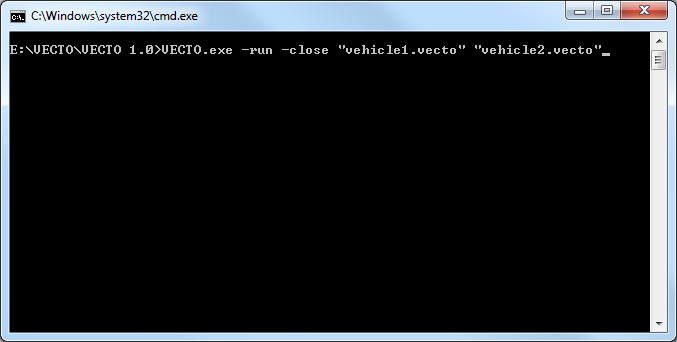

It is possible to control basic functions of VECTO via command line arguments (e.g. to automate calculations and results analysis using scripts).

### General Notes

- The order in which the arguments are provided is arbitrary.
- If a file path includes space characters (e.g. “C:\VECTO Test Files\Demo.vecto”) then double quotes have to be used (as in the picture above).
- If not the complete file path is defined (e.g. “file1.vecto” instead of “c:\data\file1.vecto”) then VECTO expects the file in the application directory (where VECTO.exe is located).

### Engineering/Declaration Mode

```
    VECTO.exe -run [-close] [file1.vecto file2.vecto ... fileN.vecto]
```

Runs calculation(s) either with the provided .vecto file(s) or (if no file names are defined) with the files already loaded on start up*. If -**close** is used then VECTO closes after calculations are done.

### Batch Mode

```
    VECTO.exe -run -batch [-close] [file1.vecto file2.vecto ... fileN.vecto] [cycle1.vdri cycle2.vdri ... cycleN.vdri]
```

Switches to BATCH mode and runs with the provided .vecto and .vdri files. If no files are defined the pre-loaded files* are used. If -**close** is used then VECTO closes after calculations are done.

### Opening files

```
    VECTO.exe file1.xxx
```

If the file has one of the following extensions it is opened with the associated editor dialog: .vecto, .vgbx, .veng, .vveh. Note: if more than one .vecto file is provided they will be loaded in the file list (replacing the pre-loaded list*) instead.

*pre-loaded files: When VECTO starts it loads the file lists (.vecto, .vdri) of the last session, see Application Files. These files can be changes manually if VECTO is not running.

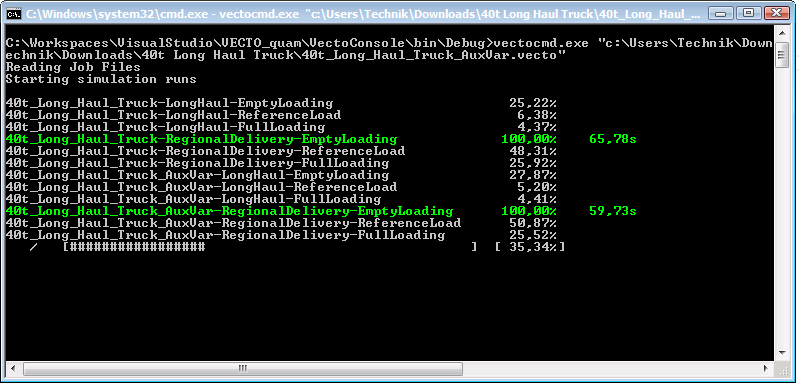

The Vecto 3.x commandline tool runs completely without a graphical user interface. If multiple job-files are specified or a job-file contains multiple simulation runs (i.e., multiple cycles and/or loadings) these simulations are executed in parallel. Vectocmd supports both types of input files, JSON (in engineering and declaration mode) and XML (Declaration mode only).

The basic usage is as follows

```
    vectocmd.exe [-h] [-v] FILE1.(vecto|xml) [FILE2.(vecto|xml) ...]
```

### List of command line arguments

- FILE1.vecto [FILE2.vecto …]: A list of vecto-job files (with the extension: .vecto). At least one file must be given. Delimited by whitespace.
- -t: output information about execution times
- -mod: write mod-data in addition to sum-data
- -eng: switch to engineering mode (implies -mod)
- -v: Shows verbose information (errors and warnings will be displayed)
- -vv: Shows more verbose information (infos will be displayed)
- -vvv: Shows debug messages (slow!)
- -vvvv: Shows all verbose information (everything, slow!)
- -V: show version information
- -h: Displays this help.

# Calculation Modes

VECTO supports different calculation modes for declaring a vehicle, validation of test-results, or experimenting with different parameters and components. These modes are described here.

- **Declaration Mode**

  In this mode a vehicle can be declared. Many simulation parameters are predefined to provide a generic way of comparing the emissions.
- **Engineering Mode**

  This mode is for experimenting and validation of a vehicle. There exist several options how the driving cycle may be defined (Target speed, Measured Speed, Pwheel).
- **Engine Only Mode**

  This mode is for validation of a measured engine component. Only the engine is simulated in this mode.

In the GUI the Calculation Mode can be changed via the Options Tab of the Main Form.

In the Command Line the Calculation Mode is Declaration by default, but can be changed to Engineering with the “-eng” flag.

A so called Batch Mode exists in VECTO v2.2, which simulates every given job file with every given cycle file. This has nothing to do with the command line, it is just a convenience function to combine job files and cycle files.

VECTO V3.x doesn’t support Batch mode anymore. The same functionality can be achieved by referencing every needed cycle file in the job files.

## Engineering Mode

The Engineering Mode lets the user define every aspect in the components of the vehicle and the driving cycle. This is for experimenting and validation purposes.

In this mode the given list of job files is simulated with the respective driving cycles. Each job file defines a separate vehicle.

This is the default calculation mode in VECTO V2.

In VectoCMD V3.x the default mode is Declaration Mode.

### Requirements

- One or more checked job files in the Job List
- Each job file must include at least one driving cycle

### Results

- Modal results (.vmod). One file for each vehicle/cycle combination.
- Sum results (.vsum). One file for each invocation of VECTO.

### Options

The Driving Cycle determines the simulation method in engineering mode. The option depends directly on the driving cycle input and cannot be set explicitely. For more information about the formats see Driving Cycles.

- **Target speed, distance-based**

  This option is the a target vehicle speed distance based cycle (like in Declaration Mode). With this option experiments can be made by the manufacturer.
- **Measured speed, time-based**

  Driving Mode where the actual speed from measurements is simulated.
- **Measured speed with gear, time-based**

  Driving Mode where the actual speed from measurements is simulated. Also defines the chosen gear.
- **Pwheel (SiCo) Mode, time-based**

  In Pwheel mode the measured power at the wheels is given, and the simulation takes that as input.

## Declaration Mode

In Declaration Mode many input parameters are predefined for the official certification. They are locked in the user interface and will automatically be set by VECTO during calculation. Calculations will be performed for each mission profile (of the corresponding HDV class) with three different loadings each: Empty, full, and reference loading.

Declaration Mode can be activated in the Options Tab.

### Requirements

- One or more checked job files in the Job List
- The job files don’t need to include driving cycles. These are automatically assigned.

### Results

- Modal results (.vmod). One file for each vehicle/cycle/loading combination.
- Sum results (.vsum). One file for each invocation of VECTO.
- Results overview (.pdf). One file for each job.

## Engine-Only Mode

When this mode is enabled in the Job File then VECTO only calculates the fuel consumption based on a load cycle (engine speed and torque). In the Job File only the following parameters are needed:

- Filepath to the Engine File (.veng)
- Driving Cycles including engine torque (or power) and engine speed

The driving cycle also has to be in a special format which is described here: Engine Only Driving Cycle.

## Batch Mode

In Batch Mode a list of vehicles is run with a list of driving cycles. Each vehicle defined in the Job List is calculated with each driving cycle defined in the Driving Cycle List. Note that the Driving Cycle List is only visible if Batch Mode is enabled in the Main Form / Options Tab.

### Requirements

- One or more checked job files in the Job List. The job files don’t need to include driving cycles. These are ignored in Batch mode.
- One or more checked driving cycles in the Dricing Cycle List

### Results

- Modal results (.vmod) for each job file and driving cycle. One file for each vehicle/cycle combination.
- Average/sum results (.vsum / .vsum.json). One file in total containing results for each vehicle/cycle combination.

VECTO V3.x doesn’t support Batch mode anymore. The same functionality can be achieved by referencing every needed cycle file in the job files.

# Simulation Models

In this chapter the used component models for the simulation are described.

- Driver: Acceleration Limiting
- Driver: Look-Ahead Coasting
- ADAS: Overspeed / Eco-Roll
- Vehicle: Cross Wind Correction
- Vehicle: Rolling Resistance Coefficient
- Engine Start/Stop
- Engine: Fuel Consumption Calculation
- Engine: Transient Full Load
- Engine: WHTC Correction
- Gear Shift Model
- Torque Converter Model
- Auxiliaries
- Engine Only Mode
- Pwheel-Input (SiCo Mode)

## Acceleration Limiting

VECTO limits the vehicle acceleration and deceleration depending on current vehicle speed, to model a realistic driver behavior. These limits are defined in the Acceleration Limiting Input File (.vacc), which can be set in the Job File. In Declaration mode this is already predefined.

- If the engine can’t provide the required power, the vehicle might accelerate slower than the defined driver limit.
- The minimum deceleration can always be maintained via the brakes.
- In Measured Speed Mode these limits are not used, due to the nature of this mode (speeds and accelerations are already real measured values, therefore VECTO uses them directly without limitation).

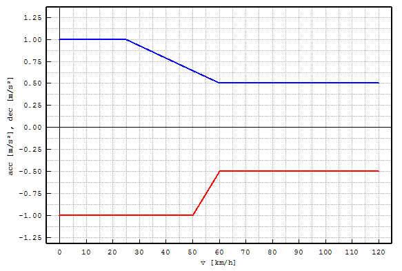

The graph shows the acceleration and deceleration limits depending on the current vehicle speed.

## Look-Ahead Coasting

Like Overspeed, Look-Ahead Coasting is a function that aims on modelling real-life driver behaviour. It is a forward-looking function that detects forthcoming reductions in target speed in the mission profile (e.g. speed limit, etc.) and induces an early deceleration using engine braking before applying mechanical brakes according to the deceleration limit.

The implemented approach uses a predefined target deceleration (a<sub>lookahead</sub>) to calculate the deceleration time for each particular target speed change.

[figure not shown]

At the resulting deceleration start point the model calculates the coasting trajectory until it meets the brake deceleration trajectory. The resulting deceleration consists of a coasting phase followed by combined mechanical/engine braking. If Look-Ahead Coasting is disabled only the braking phase according to the deceleration limit will be applied.

**Parameters in Job File:**

- **Target Retardation** = a<sub>lookahead</sub>
- **Minimum speed**. Below this speed the function is disabled.

## Overspeed / Eco-Roll

Both functions control the vehicle’s behaviour on uneven road sections (slope ≠ 0) and can be configured in the Job File’s Driver Assist Tab. Overspeed is designed to model an average driver’s behaviour without the aid of driver assistance systems. Eco-Roll represents an optional driver assistance feature. For this reason vehicles without Eco-Roll should always have the Overspeed function enabled.

### Overspeed

Overspeed activates as soon as the total power demand at the wheels (Pwheel) falls below zero, i.e. the vehicle accelerates on a negative slope. The clutch remains closed, engine in motoring operation, and the vehicle accelerates beyond the cycle’s target speed. When the speed limit (target speed plus **Max. Overspeed**) is reached the mechanical brakes are engaged to prevent further acceleration.

[figure not shown]

*Example with target (purple) and actual speed (orange) on the top left axis, slope (brown) on the top right axis. The bottom graph shows engine power (blue), motoring curve (orange) and mechanical brake power (green). In this example Overspeed is allowed until the vehicle’s speed exceeds target speed by 5 [km/h].*

**Parameters in Job File:**

- **Minimum speed [km/h]**. Below this speed the function is disabled.
- **Max. Overspeed [km/h]** (relative to target speed)

### Eco-Roll

Instead of using the engine brake (with no fuel consumption) Eco-Roll shifts to Neutral, engine idling, to minimize deceleration and maximize the vehicle’s roll out distance. During this phase the engine has to overcome its own idling losses and the power demand from the auxiliaries. The engine is engaged again if the speed exceeds the speed limits defined by Max. Over-/Underspeed.

[figure not shown]

*Example of Eco-Roll. Target (purple) and actual speed (orange) on the top left axis, slope (brown) on the top right axis. The bottom graph shows engine power (blue), motoring curve (orange) and mechanical brake power (green). The engine is idling while the vehicle rolls freely and braking when the upper speed limit is reached.*

**Parameters in Job File:**

- **Minimum speed [km/h]** Below this speed the function is disabled.
- **Max. Overspeed [km/h]** (relative to target speed)
- **Max. Underspeed [km/h]** (relative to target speed)

## Cross Wind Correction

VECTO offers three different modes to consider cross wind influence on the drag coefficient. It is configured in the Vehicle File.

### Speed dependent correction (Declaration Mode)

This is the mode which is used in Declaration Mode. The speed dependent C<sub>d</sub>A curve (see below) is calculated based on generic parameters for each vehicle class and the C<sub>d</sub>A value from the Vehicle File.

### Speed dependent correction (User-defined)

The base C<sub>d</sub>A value (see Vehicle File) is corrected with a user-defined speed dependent scaling function. A vcdv-File is needed for this calculation.

The C<sub>d</sub>A value given in the vehicle configuration is corrected depending on the vehicle’s speed and the C<sub>d</sub> scaling factor from the input file as follows:

$C_dA_{effective} = C_dA * C_d(v_{veh})$

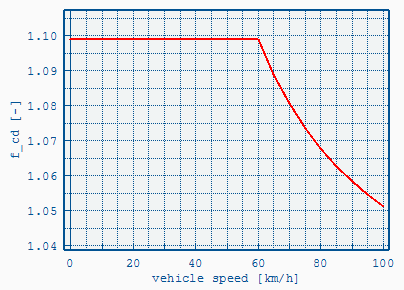

### Correction using Vair & Beta Input

The actual (measured) air speed and direction can be used to correct cross-wid influence if available. A vcdb-File is needed for this calculation. This file defines a ΔC<sub>d</sub>A value in [m²] depending on the wind angle. The driving cycle must include the air speed relative to the vehicle v<sub>air</sub> (<vair_res>) and the wind yaw angle (<vair_beta>).

The C<sub>d</sub>A value given in the vehicle configuration is corrected depending on the wind speed and wind angle (given in the driving cycle) using the input file as follows:

$C_dA_{effective} = C_dA + {\Delta}C_d(\beta)$

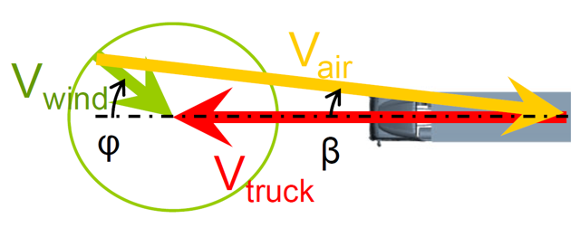

## Rolling Resistance Coefficient

with:

| RRC | [-] | Total rolling resistance coefficient used for calculation | [calculated] |
| --- | --- | --- | --- |
| s<sub>(i)</sub> | [-] | Relative axle load. Defined in the Vehicle File. | [user input] |
| RRC<sub>ISO(i)</sub> | [-] | …Tyre RRC according to ISO 28580. Defined in the Vehicle File. | [user input] |
| w<sub>(i)</sub> | [-] | Number of tyres (4 if Twin Tyres, else 2). Defined in the Vehicle File. | [user input] |
| F<sub>zISO(i)</sub> | [N] | Tyre test load according to ISO 28580 (85% of max. load capacity). Defined in the Vehicle File. | [user input] |
| m | [kg] | Vehicle mass plus loading. | [calculated] |
| g | [m/s²] | Earth gravity acceleration (constant = 9.81, Vecto 3.x: 9.80665) | [constant model parameter] |
| β | [-] | Constant parameter = 0.9 | [constant model parameter] |

For each axle the parameters **Relative axle load, RRC<sub>ISO</sub>** and **F<sub>zISO</sub>** have to be defined. Axles with twin tyres have to be marked using the respective checkbox in the Vehicle-Editor.

## Engine Start/Stop

If enabled the engine will be turned off after the set **Activation Delay [s]** if the following conditions apply:

- Power demand ≤ 0
- Vehicle speed is below **Max Speed [km/h]**
- Engine was running for at least **Min ICE-On Time [s]**

**Parameters in Job File:**

- **Max speed [km/h]**.
- **Min ICE-On Time [s]**
- **Activation Delay [s]**

If Start/Stop is enabled the fuel consumption is corrected for not-considered auxiliary energy consumption during engine stop. See Start/Stop FC Correction.

## Fuel Consumption Calculation

The base FC value is interpolated from the stationary FC map. If necessary the base value is corrected to compensate for unconsidered auxiliary energy consumption for vehicles with Start/Stop. In Declaration Mode additionally the WHTC correction is applied, see below.

The CO<sub>2</sub> result for the actual mission profile is directly derived from the fuel consumption using a gravimetric CO<sub>2</sub>/FC factor.

### Fuel Map Interpolation

The interpolation is based on [Delaunay Triangulation](http://en.wikipedia.org/wiki/Delaunay_triangulation) and works as follows:

1. Triangulate the given rpm/torque/fuel points (= x,y,z) to create a grid of triangles with each point of the map being part of at least one triangle.
2. Find the triangle where the to-be-interpolated load point (x,y) is inside. If no triangle meets the criterion the calculation will be aborted.
3. Calculate the z-value (= fuel) of the given x,y-point in the plane of the triangle

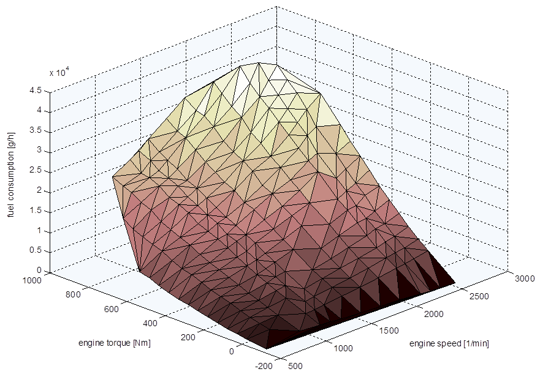

*Delaunay Triangulation Example*

### Auxiliary - Start/Stop Correction

For vehicles with Start/Stop the fuel consumption needs to be corrected to consider the wrong auxiliary energy balance caused by engine stops because VECTO uses a constant power demand for auxiliaries for the whole mission profile. The correction consists of the following steps:

1. From all 1Hz data points of the VECTO simulation, a linear regression curve (y=k*x+d) for fuel consumption (unit: grams per hour) over engine power (unit: kilo-watt) is calculated (see figure below).
2. From the difference between the energy consumed by the auxiliaries in the simulation with Start/Stop function and the target value (unit kilowatt-hours), a cycle average change in mechanical power “ΔPe” (unit kilowatt) of the internal combustion engine is calculated (using an average alternator efficiency and the cycle time with running engine).
3. The correction of the fuel consumption is performed for all 1Hz time steps using: ΔFC (unit: grams per hour) = ΔPe * k where k = gradient in the regression. If the engine is running in motoring conditions ΔFC is set to zero.

[figure not shown]

Example of a linear regression between engine power and fuel consumption

## Engine: Transient Full Load

The engine implements a PT1 behaviour to model transient torque build up.

VECTO 2 uses a PT1 function to model transient torque build up using this formula:

$P_{fld\ dyn_{i}} = \frac{1}{T(n_{i})+1} \cdot \left(P_{fld\ stat}(n_{i})+T(n_{i}) \cdot P_{act_{i-1}}\right)$

with:

- n<sub>i</sub> … current engine speed
- T(n<sub>i</sub>) … PT1 time constant at engine speed n<sub>i</sub> (col. 4 in .vfld file)
- P<sub>fld stat</sub>(n<sub>i</sub>) … Static full load at engine speed n<sub>i</sub> (col. 2 in .vfld file)
- P<sub>act i-1</sub> … Engine power in previous time step

Vecto 3 uses basically the same PT1 behavior to model transient torque build up. However, due to the dynamic time steps the formula is implemented as follows:

$P_{fld\ dyn_{i}} = P_{fld\ stat}(n_i) \cdot \left(1 - e^{-\frac{t_i^*}{\mathit{PT1}}}\right)$

where t* is computed from the dynamic full-load power in the previous simulation interval:

$t_i^* = t_{i-1}^* + dt$

$t_{i-1}^* = \mathit{PT1} \cdot ln\left(\frac{1}{1 - \frac{P_{eng_{i - 1}}}{P_{fld\ stat}(n_i)}}\right)$

## Engine: WHTC Correction

In declaration mode the fuel consumption is corrected as follows:

To prevent inconsistencies of regulated emissions and fuel consumption between the WHTC (hot part) test and the steady state fuel map as well as considering effects of transient engine behaviour a “WHTC correction factor” is used.

Based on the target engine operation points of the particular engine in WHTC the fuel consumption is interpolated from the steady state fuel map (“backward calculation”) in each of the three parts of the WHTC separately. The measured specific fuel consumption per WHTC part in [g/kWh] is then divided by the interpolated specific fuel consumption to obtain the “WHTC correction factors” CF<sub>urb</sub> (Urban), CF<sub>rur</sub> (Rural), CF<sub>mot</sub> (Motorway). For the interpolation the same method as for interpolation in VECTO is applied (Delauney triangulation).

All calculations regarding the brake specific fuel consumption from the interpolation as well as from the measurement and the three correction factors CF<sub>urb</sub>, CF<sub>rur</sub>, CF<sub>mot</sub> are fully implemented in the VECTO-Engine evaluation tool.

The total correction factor CF<sub>total</sub> depends on the mission profile and is produced in VECTO by mission profile specific weighting factors listed in the table below.

$CF_{total} = CF_{urb} \cdot WF_{urb} + CF_{rur} \cdot WF_{rur} + CF_{mot} \cdot WF_{mot}$

with the correction factor CF<sub>urb</sub>, CF<sub>rur</sub>, CF<sub>mot</sub> coming from the Engine, and weighting factors WF<sub>urb</sub>, WF<sub>rur</sub>, WF<sub>mot</sub> predefined in the declaration data:

| Mission profile | WF<sub>urb</sub> | WF<sub>rur</sub> | WF<sub>mot</sub> |
| --- | --- | --- | --- |
| Long haul | 11% | 0% | 89% |
| Regional delivery | 17% | 30% | 53% |
| Urban delivery | 69% | 27% | 4% |
| Municipial utility | 98% | 0% | 2% |
| Construction | 62% | 32% | 6% |
| Citybus | 100% | 0% | 0% |
| Interurban bus | 45% | 36% | 19% |
| Coach | 0% | 22% | 78% |

The whtc fuel consumption is then calculated with: $FC_{whtc} = FC \cdot CF_{total}$

In engineering mode no WHTC correction is applied by Vecto. For an arbitrary cycle the weighting factors are not known, hence the total correction factor CF<sub>total</sub> can not be computed. WHTC correction can be applied manually as a post-processing step.

## Gear Shift Model

The Gear Shift Model is based on shift curves that define the engine speed for up- and down- shifting as a function of engine torque. As soon as the engine operation point passes one of the shift curves a gear change is initiated.

[figure not shown]

*Example shift polygons*

- **Down-shift:**
  - As soon as the current engine speed falls below the down-shift cuve a down-shift is initiated
- **Up-shift:**
  - MT and AMT transmissions: Up-shift is initiated when the current engine speed is above the up-shift curve
  - AT transmissions: Up-shift is initiated when the next-gear engine speed is above the up-shift curve

The shift polygons are saved in the Shift Polygons Input File (.vgbs) and have to be added to the Gearbox File when not in Declaration Mode.

In Declaration Mode the generic shift polygons are computed from the engine’s full-load curve. If the maximum torque is limited by the gearbox, the minimum of the current gear and engine maximum torque will be used to compute the generic shift polygons. Note: the computation of the shift polygons uses characteristic values from the engine such as n<sub>95h</sub>, n<sub>pref</sub>, etc. which are also derived from the full-load curve.

In the Gearbox File two additional parameters are defined:

- **Torque Reserve** [%] - Required for the “**Early Upshift**” and “**Skip Gears**” options, see below.
- **Minimum shift time** [s] - Limits the time between two gear shifts in whole seconds. This rule will be ignored if rpms are too high or too low. Note that high values may cause high rpms during acceleration.

### Gear Skipping

Gear Skipping can be enabled in the Gearbox File. By default it is enabled for AMT and MT. Whenever a gear change is initiated (by crossing the up- or down-shift line) VECTO may skip one or several gears as long as the required torque reserve is provided.

[figure not shown]

### Early Upshift

Early Upshift can be enabled in the Gearbox File (Allow shift-up inside polygons). By default it is enabled for AMT only. If the next higher gear provides the required torque reserve and it’s rpm is still above down-shift-rpm VECTO will shift up.

[figure not shown]

## Torque Converter Model

**!!! The Torque Converter Model is still in development and at the moment only available in Vecto 2.2 !!!**

The torque converter is defined as (virtual) separate gear. While TC active: Iterative calculation of engine torque and speed based on TC characteristic. Creeping: Engine speed set to idling. Brakes engaged to absorb surplus torque.

[figure not shown]

### Torque converter characteristics file (.vtcc)

The file is described here.

This file defines the torque converter characteristics as described in VDI 2153:

- **Speed Ratio** (ν) = Output Speed / Input Speed
- **Torque Ratio** (μ) = Output Torque / Input Torque
- **Input Torque** (T<sub>ref(ν)</sub>) is the input torque (over ν) for a specific reference engine speed (see below).

The Input Torque at reference engine speed is needed to calculate the actual engine torque using this formula:

$T_{in} = T_{ref}(v) \cdot ( \frac{n_{in}}{n_{ref}} )^{2}$

with:

- T<sub>in</sub> = engine torque [Nm]
- T<sub>ref(ν)</sub> = reference torque at reference rpm (form .vtcc file) [Nm]
- n<sub>in</sub> = engine speed [1/min]
- n<sub>ref</sub> = reference rpm [1/min] (see below)

The torque converter characteristics must also be defined for speed ratios of more than one (ν>1) in order to calculate overrun conditions (torque<0).

### Setup for Conventional AT gearboxes

Torque converter file is defined for **torque converter only**

[figure not shown]

- Define TC gear with ratio of first (mechanical) gear
- Set transmission losses of first gear (map or constant efficiency)

[figure not shown]

### Setup for Power-distributed AT gearboxes

Torque converter file is defined for the **whole gearbox**

[figure not shown]

- Define TC gear with ratio = 1
- Set transmission efficiency to 1 (= 100%) because losses are covered by the .vtcc file.

[figure not shown]

## Auxiliaries

In VECTO a generic map-based approach was implemented to consider all types of auxiliaries. The supply power demand for each single auxiliary is defined in the driving cycle. Hence a time/distance-dependent power demand can be defined. Based on the supply power and a pre-defined efficiency map the auxiliary input power is calculated. A constant efficiency determines the losses between auxiliary and engine.

For each auxiliary the power demand is calculated using the following steps:

[figure not shown]

1. Auxiliary speed: **n<sub>aux</sub> = n<sub>Eng</sub> * TransRatio**
2. Auxiliary output power: **P<sub>auxOut</sub> = P<sub>supply</sub>/EffToSply**
3. Auxiliary input power: **P<sub>auxIn</sub> = EffMap(n<sub>Aux</sub>, P<sub>AuxOut</sub>)**
4. Auxiliary power consumption: **P<sub>aux</sub> = P<sub>auxIn</sub>/EffToEng**
5. **P<sub>aux</sub> is added to the engine’s power demand**

| n<sub>Eng</sub> | Calculated engine speed. | [1/min] |
| --- | --- | --- |
| TransRatio | Speed ratio between auxiliary and engine. Defined in the Auxiliary File. | [-] |
| n<sub>aux</sub> | Auxiliary speed | [1/min] |
| P<sub>supply</sub> | Effective supply power demand. Defined in the driving cycle. | [kW] |
| EffToSply | Consumer efficiency. Defined in the Auxiliary File. | [-] |
| P<sub>auxOut</sub> | Auxiliary output power | [kW] |
| EffMap | Auxiliary efficiency map. Defined in the Auxiliary File. | [kW] = f( [1/min], [kW] ) |
| P<sub>auxIn</sub> | Auxiliary input power | [kW] |
| EffToEng | Efficiency of auxiliary (belt/gear) drive. Defined in the Auxiliary File. | [-] |
| P<sub>aux</sub> | Mechanical auxiliary power demand at the crank shaft | [kW] |

Each auxiliary must be defined in the Job File and each driving cycle used with this vehicle must include supply power for each auxiliary. To link the supply power in the driving cycle to the correct auxiliary in the Job File an ID is used. The corresponding supply power is then named *“<Aux_ID>”*.

*Example:* *The Auxiliary with the ID “ALT” (in the Job File) is linked to the supply power in the column “<Aux_ALT>” in the driving cylce.*

## P<sub>wheel</sub>-Input (SiCo Mode)

For verification tasks it is possible to manually input the power at wheels (P<sub>wheel</sub>) which is normally calculated via longitudinal dynamics. In this case VECTO only calculates the losses between wheels and engine and adds auxiliary power demand. This mode is active as soon as P<sub>wheel</sub>, Gear and Engine Speed are defined in the driving cycle.

### Requirements

- Driving Cycle must include t, P<sub>wheel</sub> (Pwheel), Gear (Gear) and Engine Speed (n), see Driving Cycle (.vdri) format.
- The driving cycle must be time-based.

Distance Correction must be disabled (Options tab in Main Form).

**Example driving cycle with P<sub>wheel</sub> input.**

| <t> | <Pwheel> | <gear> | <n> |
| --- | --- | --- | --- |
| 1 | 0.0 | 0 | 560.0 |
| 2 | 0.0 | 0 | 560.0 |
| 3 | 14.0 | 1 | 593.2 |
| 4 | 51.9 | 1 | 705.5 |
| … | … | … | … |

# Input and Output

Vecto uses data files for input and output of data. These are stored in different formats which are listed here.

**Input:**

- JSON
- Vecto CSV

**Output:**

- JSON
- Vecto CSV
- PDF (for Declaration Report)

## CSV

Many data files in Vecto use CSV (Comma Separated Values) as common file format. They consist of a header which defines the columns and data entries which are separated by a comma (“,”).

In Vecto 3 the order of the columns is arbitrary if the column header matches the header definitions described in this user manual. If the column header does not match, a warning is written to the log file and the columns are parsed in the sequence as described in this manual as a fall-back.

### Definition

[output not shown]

Following files use the csv:

- Speed Dependent Cross Wind Correction Input File (.vcdv)
- Vair & Beta Cross Wind Correction Input File (.vcdb)
- Retarder Loss Torque Input File (.vrlm)
- Full Load and Drag Curves (.vfld)
- Fuel Consumption Map (.vmap)
- Shift Polygons Input File (.vgbs)
- Transmission Loss Map (.vtlm)
- Torque Converter Characteristics (.vtcc)
- Auxiliary Input File (.vaux)
- Driving Cycles (.vdri)
- Acceleration Limiting Input File (.vacc)
- Modal Results (.vmod)
- Summary Results (.vsum)

**Notes:** The Auxiliary Input File (.vaux) uses a modified csv format with some special headers.

### Examples

#### Exampl 1: Acceleration Limiting File

```
v [km/h],acc [m/s^2]     ,dec [m/s^2]
0       ,1.01570922360353,-0.231742702878269
5       ,1.38546581120225,-0.45346198022574
10      ,1.34993329755465,-0.565404125020508
15      ,1.29026714002479,-0.703434814668512
```

#### Example 2: Driving Cycle

```
<s>,<v>,<grad>      ,<stop>,<Padd>,<Aux_ALT1>,<Aux_ALT2>,<Aux_ALT3>
0  ,0  ,-0.020237973,2     ,6.1   ,0.25      ,0.25      ,0.25
1  ,64 ,-0.020237973,0     ,6.1   ,0.25      ,0.25      ,0.25
2  ,64 ,-0.020237973,0     ,6.1   ,0.25      ,0.25      ,0.25
3  ,64 ,-0.020237973,0     ,6.1   ,0.25      ,0.25      ,0.25
```

#### Example 3: Transmission Loss Map

```
Input Speed [rpm],Input Torque [Nm],Torque Loss [Nm]
0                ,-2500            ,77.5
0                ,-1500            ,62.5
0                ,-500             ,47.5
0                ,500              ,47.5
```

## JSON

Configuration and component files in Vecto use JSON as common file format.

Following files use JSON:

- Job
- Vehicle
- Engine
- Gearbox

## Job File

File for the definition of an job in vecto. A job contains everything what is needed to run a simulation. Can be created with the Job Editor.

- File format is JSON.
- Filetype ending is “.vecto”

Refers to other files:

- Vehicle (VVEH)
- Engine (VENG)
- Gearbox (VGBX)
- Driving Cycle (VDRI)
- Auxiliary Input File (VAUX)
- Acceleration Limiting (VACC)

**Example:**

```json
{
  "Header": {
    "CreatedBy": "Michael Krisper (Graz University of Technology)",
    "Date": "2016-03-18T14:37:05+01:00",
    "AppVersion": "3.0.2",
    "FileVersion": 2
  },
  "Body": {
    "SavedInDeclMode": false,
    "VehicleFile": "Vehicle.vveh",
    "EngineFile": "Engine.veng",
    "GearboxFile": "Gearbox.vgbx",
    "Cycles": [
      "DrivingCycle_Rural.vdri",
      "DrivingCycle_Urban.vdri"
    ],
    "Aux": [
      {
        "ID": "ALT",
        "Type": "Alternator",
        "Path": "Alternator.vaux",
        "Technology": ""
      },
      {
        "ID": "PN",
        "Type": "PneumaticSystem",
        "Path": "Pneumatic System.vaux",
        "Technology": ""
      },
      {
        "ID": "HVAC",
        "Type": "HVAC",
        "Path": "AirCondition.vaux",
        "Technology": ""
      }
    ],
    "VACC": "Driver.vacc",
    "EngineOnlyMode": true,
    "StartStop": {
      "Enabled": false,
      "MaxSpeed": 5.0,
      "MinTime": 0.0,
      "Delay": 0
    },
    "LAC": {
      "Enabled": true,
      "Dec": -0.5,
      "MinSpeed": 50.0
    },
    "OverSpeedEcoRoll": {
      "Mode": "OverSpeed",
      "MinSpeed": 70.0,
      "OverSpeed": 5.0,
      "UnderSpeed": 5.0
    }
  }
}
```

## Vehicle File

File for the definition of a vehicle in vecto. Can be created with the Vehicle Editor.

- File format is JSON.
- Filetype ending is “.vveh”

Refers to other files:

- Cross Wind Correction (VCDV, VCDB)
- Retarder Loss Map (VRLM)

**Example:**

```json
{
  "Header": {
    "CreatedBy": "Michael Krisper (Graz University of Technology)",
    "Date": "2016-03-18T14:42:45+01:00",
    "AppVersion": "3.0.2",
    "FileVersion": 7
  },
  "Body": {
    "SavedInDeclMode": false,
    "VehCat": "RigidTruck",
    "CurbWeight": 6000.0,
    "CurbWeightExtra": 0.0,
    "Loading": 0.0,
    "MassMax": 11.9,
    "CdA": 4.5,
    "rdyn": 450,
    "Rim": "15° DC Rims",
    "CdCorrMode": "CdOfVeng",
    "CdCorrFile": "CrossWindCorrection.vcdv",
    "Retarder": {
      "Type": "Secondary",
      "Ratio": 1.0,
      "File": "Retarder.vrlm"
    },
    "AxleConfig": {
      "Type": "4x2",
      "Axles": [
        {
          "Inertia": 6.0,
          "Wheels": "245/70 R19.5",
          "AxleWeightShare": 0.0,
          "TwinTyres": false,
          "RRCISO": 0.008343465,
          "FzISO": 20800.0
        },
        {
          "Inertia": 6.0,
          "Wheels": "245/70 R19.5",
          "AxleWeightShare": 0.0,
          "TwinTyres": true,
          "RRCISO": 0.00943769,
          "FzISO": 20800.0
        }
      ]
    }
  }
}
```

## Speed Dependent Cross Wind Correction Input File (.vcdv)

The file is needed for speed dependent Cross Wind Correction. The file uses the VECTO CSV format.

- Filetype: .vcdv
- Header: **v_veh [km/h], Cd [-]**
  - **v_veh [km/h]**: the vehicle speed
  - **Cd [-]**: the scaling factor which will be multiplied with the base C<sub>d</sub>A value.
- Requires at least 2 data entries

**Example:**

```
v_veh [km/h],Cd [-]
0           ,1.173
5           ,1.173
10          ,1.173
15          ,1.173
20          ,1.173
25          ,1.173
30          ,1.173
35          ,1.173
40          ,1.173
45          ,1.173
50          ,1.173
55          ,1.173
60          ,1.173
65          ,1.153
70          ,1.136
75          ,1.121
80          ,1.109
85          ,1.099
90          ,1.090
95          ,1.082
100         ,1.07
```

## Vair & Beta Cross Wind Correction Input File (.vcdb)

The file is needed for Vair & Beta Cross Wind Correction. The file uses the VECTO CSV format.

- Filetype: .vcdb
- Header: **beta [°], delta CdA [m^2]**
  - **beta [°]**: the wind yaw angle (0° means that the wind comes directly from the front)
  - **delta CdA [m^2]**: The ΔC<sub>d</sub>A value which will be added to the base C<sub>d</sub>A value.
- Requires at least 2 data entries

**Example:**

```
beta [°],delta CdA [m^2]
0       ,0.00
1       ,0.07
2       ,0.21
3       ,0.40
4       ,0.64
5       ,0.90
6       ,1.19
7       ,1.48
8       ,1.76
9       ,2.02
10      ,2.25
20      ,3.14
40      ,3.24
60      ,-0.76
80      ,-4.76
100     ,-9.01
120     ,-15.01
140     ,-21.01
160     ,-20.86
180     ,-16.15
```

## Retarder Loss Torque Input File (.vrlm)

This file is used to define retarder idling losses. It can be used for primary and secondary retarders and must be set in the Vehicle File. The file uses the VECTO CSV format.

- Filetype: .vrlm
- Header: **Retarder Speed [1/min], Torque Loss [Nm]**
- Requires at least 2 data entries

**Example:**

```
Retarder Speed [1/min],Torque Loss [Nm]
0                     ,10
100                   ,10.02
200                   ,10.08
300                   ,10.18
...
```

## Engine File

File for the definition of an engine in Vecto. Can be created with the Engine Editor.

- File format is JSON.
- Filetype ending is “.veng”

Refers to other files:

- Full Load And Drag Curve (VFLD)
- Fuel Consumption (VMAP)

**Example:**

```json
{
  "Header": {
    "CreatedBy": "Michael Krisper (Graz University of Technology",
    "Date": "2016-03-18T14:48:38+01:00",
    "AppVersion": "3.0.2",
    "FileVersion": 3
  },
  "Body": {
    "SavedInDeclMode": false,
    "ModelName": "Engine",
    "Displacement": 7700.0,
    "IdlingSpeed": 600.0,
    "Inertia": 3.789,
    "FullLoadCurve": "EngineFullLoadCurve.vfld",
    "FuelMap": "FuelConsumptionMap.vmap",
    "WHTC-Urban": 0.97,
    "WHTC-Rural": 0.99,
    "WHTC-Motorway": 1.05
  }
}
```

## Full Load and Drag Curves (.vfld)

This file contains the full load and drag curves and the PT1 values for the transient full load calculation. The file uses the VECTO CSV format.

- Filetype: .vfld
- Header: **engine speed [1/min], full load torque [Nm], motoring torque [Nm], PT1 [s]**
  - **engine speed [1/min]**: the engine speed in rpm.
  - **full load torque [Nm]**: the maximum possible full load for the engine speed.
  - **motoring torque [Nm]**: the minimum possible drag load in motoring for the engine speed.
  - **PT1 [s]**: the PT1 constant for the transient full load calculation.
- Requires at least 2 data entries

**Example:**

```
engine speed [1/min],full load torque [Nm],motoring torque [Nm],PT1 [s]
560                 ,1180                 ,-149                ,0.6
600                 ,1282                 ,-148                ,0.6
800                 ,1791                 ,-149                ,0.6
...
```

## Fuel Consumption Map (.vmap)

The FC map is used to interpolate the base fuel consumption before corrections are applied. For details see Fuel Consumption Calculation. The file uses the VECTO CSV format.

- Filetype: .vmap
- Header: **engine speed [rpm], torque [Nm], fuel consumption [g/h]**
- Requires at least 3 data entries
- The map must cover the full engine range between full load and motoring curve.

Extrapolation of fuel consumption map is possible in Engineering Mode (with warnings!). In Declaration Mode it is not allowed.

**Example:**

```
engine speed [rpm],torque [Nm],fuel consumption [g/h]
600               ,-45        ,0
600               ,0          ,767
600               ,100        ,1759
600               ,200        ,2890
600               ,300        ,4185
600               ,400        ,5404
600               ,500        ,6535
600               ,600        ,7578
...
```

## Gearbox File

File for the definition of a gearbox in Vecto. Can be created with the Gearbox Editor.

- File format is JSON.
- Filetype ending is “.vgbx”

Refers to other files:

- Shift Polygon (VGBS)
- Loss Map (VTLM)
- Full Load Curve (VFLD)
- Torque Converter (VTCC)

**Example:**

```json
{
  "Header": {
    "CreatedBy": "Michael Krisper (Graz University of Technology)",
    "Date": "2016-03-18T14:37:18+01:00",
    "AppVersion": "3.0.2",
    "FileVersion": 5
  },
  "Body": {
    "SavedInDeclMode": false,
    "ModelName": "Generic 8 Gears",
    "Inertia": 0.0,
    "TracInt": 1.0,
    "Gears": [
      {
        "Ratio": 3.2,
        "LossMap": "Axle.vtlm"
      },
      {
        "Ratio": 6.4,
        "LossMap": "Indirect Gear.vtlm",
        "TCactive": false,
        "ShiftPolygon": "ShiftPolygon.vgbs",
        "FullLoadCurve": "<NOFILE>"
      },
      {
        "Ratio": 4.6,
        "LossMap": "Indirect Gear.vtlm",
        "TCactive": false,
        "ShiftPolygon": "ShiftPolygon.vgbs",
        "FullLoadCurve": "<NOFILE>"
      },
      {
        "Ratio": 3.4,
        "LossMap": "Indirect Gear.vtlm",
        "TCactive": false,
        "ShiftPolygon": "ShiftPolygon.vgbs",
        "FullLoadCurve": "<NOFILE>"
      },
      {
        "Ratio": 2.6,
        "LossMap": "Indirect Gear.vtlm",
        "TCactive": false,
        "ShiftPolygon": "ShiftPolygon.vgbs",
        "FullLoadCurve": "<NOFILE>"
      },
      {
        "Ratio": 1.9,
        "LossMap": "Indirect Gear.vtlm",
        "TCactive": false,
        "ShiftPolygon": "ShiftPolygon.vgbs",
        "FullLoadCurve": "<NOFILE>"
      },
      {
        "Ratio": 1.3,
        "LossMap": "Indirect Gear.vtlm",
        "TCactive": false,
        "ShiftPolygon": "ShiftPolygon.vgbs",
        "FullLoadCurve": "<NOFILE>"
      },
      {
        "Ratio": 1,
        "LossMap": "Direct Gear.vtlm",
        "TCactive": false,
        "ShiftPolygon": "ShiftPolygon.vgbs",
        "FullLoadCurve": "<NOFILE>"
      },
      {
        "Ratio": 0.75,
        "LossMap": "Indirect Gear.vtlm",
        "TCactive": false,
        "ShiftPolygon": "ShiftPolygon.vgbs",
        "FullLoadCurve": "<NOFILE>"
      }
    ],
    "TqReserve": 20.0,
    "SkipGears": true,
    "ShiftTime": 2,
    "EaryShiftUp": true,
    "StartTqReserve": 20.0,
    "StartSpeed": 2.0,
    "StartAcc": 0.6,
    "GearboxType": "AMT",
    "TorqueConverter": {
      "Enabled": false,
      "File": "<NOFILE>",
      "RefRPM": 0.0,
      "Inertia": 0.0
    }
  }
}
```

## Shift Polygons Input File (.vgbs)

Defines up- and down-shift curves. See Gear Shift Model for details. The file uses the VECTO CSV format.

- Filetype: .vgbs
- Header: **engine torque [Nm], downshift rpm [1/min], upshift rpm [1/min]**
- Requires at least 2 data entries

**Example:**

```
engine torque [Nm],downshift rpm [1/min],upshift rpm [1/min]
-400              ,560                  ,1289
759               ,560                  ,1289
1252              ,742                  ,1289
2372              ,1155                 ,1942
...
```

**Example Graph:**

[figure not shown]

A typical shift curve.

## Transmission Loss Map

This file defines losses in gearbox and axle transmission and must be provided for each gear in the Gearbox File. The file uses the VECTO CSV format.

- Filetype: .vtlm
- Header: **Input Speed [rpm], Input Torque [Nm], Torque Loss [Nm]**
- Requires at least 3 data entries

Input speed and input torque are meant at the engine-side.

**Example:**

```
Input Speed [rpm],Input Torque [Nm],Torque Loss [Nm]
0                ,-350             ,6.81
0                ,-150             ,5.81
0                ,50               ,5.31
0                ,250              ,6.31
0                ,450              ,7.31
0                ,650              ,8.31
```

#### Sign of torque values

- Input Torque >0 means normal driving operation.
- Input Torque <0 means motoring operation. **The Torque Loss Map must include negative torque values for engine motoring operation!**
- Torque Loss is always positive!

#### Calculation of Output Torque

VECTO calculates the output torque using this formula, independent from the current operation mode (driving/braking):

$T_{output} = (T_{input} - T_{loss}) * r_{gear}$

with:

- T<sub>output</sub> … Output torque
- T<sub>input</sub> … Input torque
- T<sub>loss</sub> … Torque loss
- r<sub>gear</sub> … The tranmission ratio for the gurrent gear

## Torque Converter Characteristics (.vtcc)

**!!! The Torque Converter Model is still in development !!!**

The file uses the VECTO CSV format.

- Filetype: .vtlm
- Header: **Speed Ratio, Torque Ratio, Input Torque at reference rpm**
- Requires at least 2 data entries

See Torque Converter Model for more information about the component model.

## Auxiliary Input File (.vaux)

This file is used to configure a single auxiliary. Multiple .vaux files can be defined in the Job File via the Auxiliary Dialog. The file uses the VECTO CSV format with three additional parameters on top of the efficiency map.

See Auxiliaries for details on how the power demand for each auxiliary is calculated.

- Filetype: .vaux
- Multiple Header must exist in the following sequence:
  - **Transmission ration to engine rpm [-]**: Speed ratio between auxiliary and engine. Followed by just one value line.
  - **Efficiency to engine [-]**: Efficiency of auxiliary (belt/gear) drive. Followed by just one value line.
  - **Efficiency auxiliary to supply [-]**: Consumer efficiency. Followed by just one value line.
  - **Auxiliary speed [rpm], Mechanical power [kW], Supply power [kW]**
    - Actual map entries
- Requires exact one value for the first 3 headers, and at least 3 data lines for the map entries.

**Example:**

```
Transmission ration to engine rpm [-]
4.078
Efficiency to engine [-]
0.96
Efficiency auxiliary to supply [-]
1
Auxiliary speed [rpm],Mechanical power [kW],Supply power [kW]
1415                 ,0.07                 ,0
1415                 ,0.87                 ,0.53
1415                 ,1.03                 ,0.64
1415                 ,1.17                 ,0.75
...
```

## Driving Cycles

A Driving Cycle defines the parameters of a simulated route in Vecto. It is either time-based or distance-based and has different fields depending on the driving cycle type. The basic file format is Vecto-CSV and the file type ending is “.vdri”. A Job must have at least one driving cycle (except in Declaration mode, where the driving cycles are predefined).

### Declaration Mode Cycles

In Declaration Mode driving cycles are automatically chosen depending on vehicle category and cannot be changed by the user. These predefined cycles are of type target-speed, distance-based.

- Coach: 275km
- Construction: 21km
- Heavy Urban: 30km
- Inter Urban: 123km
- Long Haul: 100km
- Municipal Utility: 10km
- Regional Delivery: 26km
- Sub Urban: 23km
- Urban: 40km
- Urban Delivery: 28km

### Engineering Mode: Target-Speed, Distance-Based Cycle

This driving cycle defines the target speed over distance. Vecto tries to achieve and maintain this target speed.

Header: **<s>, <v>, <stop>***[, <Padd>][, <grad>][, <vair_res>, <vair_beta>][, <Aux_ID>]*

[output not shown]

**Example:**

| <s> [m] | <v> [km/h] | <stop> [s] | <grad> [%] | <Padd> [kW] |
| --- | --- | --- | --- | --- |
| 0 | 10 | 10 | 2.95 | 1.5 |
| 1 | 20 | 0 | 2.97 | 1.3 |
| 2 | 35 | 0 | 3.03 | 1.3 |
| 3 | 50 | 0 | 2.99 | 1.3 |

### Engineering Mode: Measured-Speed, Time-Based Cycle

This driving cycle defines the actual measured speed over time. Vecto tries to simulate the vehicle model using this speed as the actual vehicle speed. Due to differences in the real and simulated shift strategies a short difference in speed could occur, but Vecto immediately tries to catch up after the gear is engaged again.

Header: **<t>, <v>***[, <grad>][, <Padd>][, <vair_res>, <vair_beta>][, <Aux_ID>]*

[output not shown]

**Example:**

| <t> [s] | <v> [km/h] | <grad> [%] | <Padd> [kW] |
| --- | --- | --- | --- |
| 0 | 0 | 2.95 | 1.5 |
| 1 | 0.6 | 2.97 | 1.3 |
| 2 | 1.2 | 3.03 | 1.3 |
| 3 | 2.4 | 2.99 | 1.3 |

### Engineering Mode: Measured-Speed With Gear, Time-Based Cycle

This driving cycle defines the actual measured speed of the vehicle, the gear, and the engine speed over time. It overrides the shift strategy of Vecto and also directly sets the engine speed.

Header: **<t>, <v>, <n>, <gear>***[, <grad>][, <Padd>][, <vair_res>, <vair_beta>][, <Aux_ID>]*

[output not shown]

**Example:**

| <t> [s] | <v> [km/h] | <n> [rpm] | <gear> [-] | <grad> [%] | <Padd> [kW] |
| --- | --- | --- | --- | --- | --- |
| 0 | 0 | 600 | 0 | 2.95 | 1.5 |
| 1 | 0.6 | 950 | 3 | 2.97 | 1.3 |
| 2 | 1.2 | 1200 | 3 | 3.03 | 1.3 |
| 3 | 2.4 | 1400 | 3 | 2.99 | 1.3 |

### Engineering Mode: Pwheel (SiCo), Time-Based

This driving cycle defines the power measured at the wheels over time. Vecto tries to simulate the vehicle with this power requirement.

Header: **<t>, <Pwheel>, <gear>, <n>***[, <Padd>]*

| Identifier | Unit | Quantity Description |
| --- | --- | --- |
| **t** | [s] | The absolute time. Must always be increasing. |
| **Pwheel** | [kW] | Power at the wheels. |
| **gear** | [-] | The current gear. Must be >= 0 (0 is neutral). |
| **n** | [rpm] | The actual engine speed. Must be >= 0 rpm. |
| *Padd* | [kW] | Additional auxiliary power demand. This power demand will be directly added to the engine power. Must be >= 0 kW. |

**Example:**

| <t> [s] | <Pwheel> [kW] | <gear> [-] | <n> [rpm] | <Padd> [kW] |
| --- | --- | --- | --- | --- |
| 0 | 0 | 0 | 600 | 1.5 |
| 1 | 4.003 | 3 | 950 | 1.3 |
| 2 | 15.333 | 3 | 1200 | 1.3 |
| 3 | 50.56 | 3 | 1400 | 1.3 |

### Engine Only Mode: Engine Only Driving Cycle

This driving cycle directly defines the power or torque at the output shaft of the engine over time. Vecto add the engine’s inertia to the given power demand and simulates the engine.

Header: **<t>, <n>, (<Pe>|<Me>)***[, <Padd>]*

| Identifier | Unit | Description |
| --- | --- | --- |
| **t** | [s] | The absolute time. Must always be increasing. |
| **n** | [rpm] | The actual engine speed. Must be >= 0 rpm. |
| **Pe** | [kW] | The power at the output shaft of the engine. Either <Pe> or <Me> must be defined. |
| **Me** | [Nm] | The torque at the output shaft of the engine. Either <Pe> or <Me> must be defined. |
| *Padd* | [kW] | Additional auxiliary power demand. This power demand will be directly added to the engine power. Must be >= 0 kW. |

**Example:**

| <t> [s] | <n> [rpm] | <Pe> [kW] | <Padd> [kW] |
| --- | --- | --- | --- |
| 0 | 600 | 0 | 1.5 |
| 1 | 950 | 25.3 | 1.3 |
| 2 | 1200 | 65.344 | 1.3 |
| 3 | 1400 | 110.1 | 1.3 |

To explicitly define *motoring operation* use the **<DRAG>** keyword as power demand (column <Pe> or <Me>). VECTO v2 replaces the keyword with the corresponding motoring torque/power from the drag curve during calculation (see Full Load and Drag Curve File).

## Acceleration Limiting Input File (.vacc)

The file is used for Acceleration Limiting. It defines the acceleration and deceleration limits as function of vehicle speed. The filepath has to be defined in the Job File. The file uses the VECTO CSV format.

- Filetype: .vacc
- Header: **v [km/h], acc [m/s^2], dec [m/s^2]**
  - **v [km/h]**: the vehicle speed. Must be >= 0 km/h.
  - **acc [m/s^2]**: the maximum acceleration. Must be > 0 m/s^2.
  - **dec [m/s^2]**: the maximum deceleration. Must be < 0 m/s^2.
- Requires at least 2 data entries
- Data should cover the whole possible range of vehicle speeds

**Example Data:**

[output not shown]

**Example Graph:**

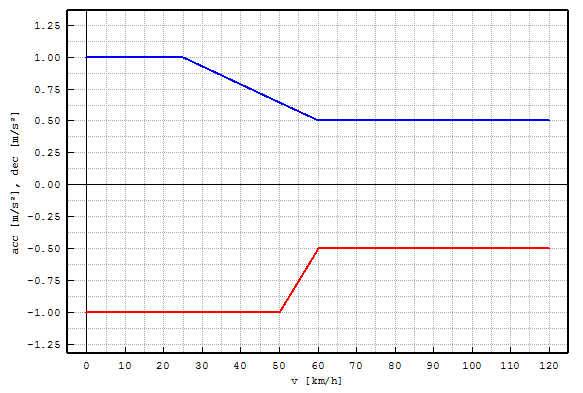

The graph shows the acceleration and deceleration limits depending on the current vehicle speed.

## Modal Results (.vmod)

Modal results are only created if enabled in the Options tab. One file is created for each calculation and stored in the same directory as the .vecto file.

*Quantities:*

| **Name** | **Unit** | **Description** |
| --- | --- | --- |
| time | [s] | Time step. |
| dist | [km] | Travelled distance. |
| v_act | [km/h] | Actual vehicle speed. |
| v_targ | [km/h] | Target vehicle speed. |
| acc | [m/s²] | Vehicle acceleration. |
| grad | [%] | Road gradient. |
| n | [1/min] | Engine speed. |
| Tq_eng | [Nm] | Engine torque. |
| Tq_clutch | [Nm] | Torque at clutch (before clutch, engine-side) |
| Tq_full | [Nm] | Full load torque |
| Tq_drag | [Nm] | Motoring torque |
| Pe_eng | [kW] | Engine power. |
| Pe_full | [kW] | Engine full load power. |
| Pe_drag | [kW] | Engine drag power. |
| Pe_clutch | [kW] | Engine power at clutch (equals **Pe** minus loss due to rotational inertia **Pa Eng**). |
| Gear | [-] | Gear. “0” = clutch opened / neutral. |
| Ploss GB | [kW] | Gearbox losses. |
| Ploss Diff | [kW] | Losses in differential / axle transmission. |
| Ploss Retrader | [kW] | Retarder losses. |
| Pa Eng | [kW] | Rotational acceleration power: Engine. |
| Pa GB | [kW] | Rotational acceleration power: Gearbox. |
| Pa Veh | [kW] | Vehicle acceleration power. |
| Proll | [kW] | Rolling resistance power demand. |
| Pair | [kW] | Air resistance power demand. |
| Pgrad | [kW] | Power demand due to road gradient. |
| Paux | [kW] | Total auxiliary power demand. |
| Pwheel | [kW] | Total power demand at wheel = sum of rolling, air, acceleration and road gradient resistance. |
| Pbrake | [kW] | Brake power. Drag power is included in **Pe**. |
| Paux_xxx | [kW] | Power demand of Auxiliary with ID xxx. See also Aux Dialog and Driving Cycle. |
| FC-Map | [g/h] | Fuel consumption interpolated from FC map. |
| FC-AUXc | [g/h] | Fuel consumption after Auxiliary-Start/Stop Correction. (Based on FC.) |
| FC-WHTCc | [g/h] | Fuel consumption after WHTC Correction. (Based on FC-AUXc.) |
| TCv | [-] | Torque converter speed ratio |
| TCµ | [-] | Torque converter torque ratio |
| TC_M_Out | [Nm] | Torque converter output torque |
| TC_n_Out | [1/min] | Torque converter output speed |

In Vecto 3.0.2 the structure of the modal data output has been revised and re-structured. Basicaly for every powertrain component the .vmod file contains the power at the input shaft and the individual power losses for every component. For the engine the power, torque and engine speed at the output shaft is given along with the internal power and torque used for computing the fuel consumption. The following table lists the columns in the .vmod file:

*Quantities:*

| **Name** | **Unit** | **Description** |
| --- | --- | --- |
| time | [s] | Absolute time. Timestamp at the middle of the current simulation interval [time - dt/2, time + dt/2] |
| dt | [s] | Length of the current simulation interval |
| dist | [m] | Distance the vehicle traveled at the end of the current simulation interval |
| v_act | [km/h] | Average vehicle speed in the current simulation interval |
| v_targ | [km/h] | Target speed |
| acc | [m/s^2] | Vehicle’s acceleration, constant during the current simulation interval |
| grad | [%] | Road gradient |
| Gear | [-] | Gear. “0” = clutch opened / neutral |
| n_eng_avg | [1/min] | Average engine speed in the current simulation interval. Used for interpolation of the engine’s fuel consumption |
| T_eng_fcmap | [Nm] | Engine torque used for interpolation of the engine’s fuel consumption. T_eng_fcmap is the sum of torque demand on the output shaft, torque demand of the auxiliaries, and engine’s inertia torque |
| Tq_full | [Nm] | Engine’s transient maximum torque (see transient full load) |
| Tq_drag | [Nm] | Engine’s drag torque, interpolated from the full-load curve |
| P_eng_fcmap | [kW] | Total power the engine has to provide, computed from n_eng_avg and T_eng_fcmap |
| P_eng_full | [kW] | Engine’s transient maximum power (see transient full load) |
| P_eng_drag | [kW] | Engine’s drag power |
| P_eng_inertia | [kW] | Power loss/gain due to the engine’s inertia |
| P_eng_out | [kW] | Power provided at the engine’s output shaft |
| P_clutch_loss | [kW] | Power loss in the clutch due to slipping when driving off |
| P_clutch_out | [kW] | Power at the clutch’s out shaft. P_clutch_out = P_eng_out - P_clutch_loss |
| P_aux | [kW] | Total power demand by the auxiliaries |
| P_gbx_in | [kW] | Power at the gearbox’ input shaft |
| P_gbx_loss | [kW] | Power loss at the gerbox, interpolated from the loss-map |
| P_gbx_inertia | [kW] | Power loss due to the gearbox’ inertia |
| P_ret_in | [kW] | Power at the retarder’s input shaft. P_ret_in = P_gbx_in - P_gbx_loss - P_gbx_inertia |
| P_ret_loss | [kW] | Power loss at the retarder, interpolated from the loss-map |
| P_axle_in | [kW] | Power at the axle-gear input shaft. P_axle_in = P_ret_in - P_ret_loss |
| P_axle_loss | [kW] | Power loss at the axle gear, interpolated from the loss-map |
| P_brake_in | [kW] | Power at the brake input shaft (definition: serially mounted into the drive train between wheels and axle). P_brake_in = P_axle_in - P_axle_loss |
| P_brake_loss | [kW] | Power loss due to braking |
| P_wheel_in | [kW] | Power at the driven wheels. P_wheel_in = P_brake_in - P_brake_loss |
| P_wheel_inertia | [kW] | Power loss due to the wheels’ inertia |
| P_trac | [kW] | Vehicle’s traction power. P_trac = P_wheel_in - P_wheel_inertia |
| P_slope | [kW] | Power loss/gain due to the road’s slope |
| P_air | [kW] | Power loss due to air drag |
| P_roll | [kW] | Rolling resistance power loss |
| P_veh_inertia | [kW] | Power loss due to the vehicle’s inertia |
| FC-Map | [g/h] | Fuel consumption interpolated from FC map. |
| FC-AUXc | [g/h] | Fuel consumption after Auxiliary-Start/Stop Correction (based on FC) |
| FC-WHTCc | [g/h] | Fuel consumption after WHTC Correction (based on FC-AUXc) |

## Summary Results (.vsum)

The .vsum file includes total / average results for each calculation run in one execution (ie. click of START Button). The file is located in the directory of the fist run .vecto file.

*Quantities:*

| Name | Unit | Description |
| --- | --- | --- |
| Job | [-] | Job number in the format “x-y” (where x = file number and y = cycle number) |
| Input File | [-] | Name of the input file |
| Cycle | [-] | Name of the cycle file |
| Status | [-] | The result status of the run (Success, Aborted) |
| time | [s] | Total simulation time |
| distance | [km] | Total traveled distance |
| speed | [km/h] | Average vehicle speed |
| altitudeDelta | [m] | Altitude difference between start and end of cycle |
| Ppos | [kW] | Average positive engine power |
| PwheelPos | [kW] | Average positive wheel power |
| Pneg | [kW] | Average negative engine power |
| FC-Final | [g/km], [l/100km], [l/100tkm] | Average fuel consumption. Final value after all corrections. |
| FC-Map | [g/h], [g/km] | Fuel consumption interpolated from Fuel Map. |
| FC-AUXc | [g/h], [g/km] | Fuel consumption after Auxiliary-Start/Stop Correction. (Based on FC-Map.) |
| FC-WHTCc | [g/h], [g/km] | Fuel consumption after WHTC Correction. (Based on FC-AUXc.) |
| CO2 | [g/km], [g/tkm] | Average CO<sub>2</sub> emissions. |
| Pbrake | [kW] | Average brake power (not including engine drag) |
| EposICE | [kWh] | Total positive engine work |
| EnegICE | [kWh] | Total negative engine work (engine brake) |
| Eair | [kWh] | Total work of air resistance |
| Eroll | [kWh] | Total work of rolling resistance |
| Egrad | [kWh] | Total work of gradient resistance |
| Eacc | [kWh] | Total work from accelerations (<0) / decelerations (>0) |
| Eaux | [kWh] | Total energy demand of auxiliaries |
| Eaux_xxx | [kWh] | Energy demand of auxiliary with ID xxx. See also Aux Dialog and Driving Cycle. |
| Ebrake | [kWh] | Total work dissipated in mechanical braking (sum of service brakes, retader and additional engine exhaust brakes) |
| Etransm | [kWh] | Total work of transmission losses |
| Eretarder | [kWh] | Total retarder losses |
| Etorqueconv | [kWh] | Total torque converter losses |
| Mass | [kg] | Vehicle mass (equals **Curb Weight Vehicle** plus **Curb Weight Extra Trailer/Body**, see Vehicle Editor) |
| Loading | [kg] | Vehicle loading (see Vehicle Editor) |
| a | [m/s²] | Average acceleration |
| a_pos | [m/s²] | Average acceleration in acceleration phases * |
| a_neg | [m/s²] | Average deceleration in deceleration phases * |
| Acc.Noise | [m/s²] | Acceleration noise |
| pAcc | [%] | Time share of acceleration phases * |
| pDec | [%] | Time share of deceleration phases * |
| pCruise | [%] | Time share of cruise phases * |
| pStop | [%] | Time share of stop phases * |

**Definition of phases:**

Acceleration Phase: a<sub>3s</sub> > 0.125 [m/s<sup>2</sup>]

Deceleration Phase: a<sub>3s</sub> < -0.125 [m/s<sup>2</sup>]

Cruise Phase: -0.125 ≤ a<sub>3s</sub> ≤ 0.125 [m/s<sup>2</sup>]

Stop Phase: v < 0.1 [m/s]

*a<sub>3s</sub> = 3-seconds-averaged acceleration*

**Definition of work (E…):**

sign > 0: positive work applied to the vehicle (e.g. from engine, from kinetic energy)

sign < 0: losses

The sum of EposICE, EnegICE, Eair, Eroll, Egrad, Eacc, Eaux, Ebrake, Etransm and Eretarder is zero (besides small rounding error for long driving cycles)

## Application Files

VECTO uses a numbers of files to save GUI settings and file lists. All files are text-based and can be changed outside of VECTO *if VECTO is not running*.

### Settings.json

This file is located in VECTO’s **config** folder. Here all parameters of the Settings Dialog are saved. The file uses the JSON format.

### Job / Cycle lists

The job and cycle lists in the Main Form are saved in the **joblist.txt** / **cyclelist.txt** files of the **config** folder.

Both files save the full file paths separated by line breaks. Additionally it is saved whether each file’s checkbox is checked or not. “?1” after a file path means the file is checked (otherwise “?0”). However, this information can be omitted in which case the file will be loaded in checked state.

### LOG.txt

The tabulator-separated log file saves all messages of the Main Form’s Message List and is located in VECTO’s program directory. The file is restarted whenever the Logfile Size Limit is reached.One backup is always stored as LOG_backup.txt.

### License file

The license file license.dat is located in VECTO’s program directory. Without a valid lisence file VECTO won’t run.

It no valid license file is provided with your VECTO version please contact vecto@jrc.ec.europa.eu.

# Changelog

**VECTO 3.0.2**

*Build 434 (2016-03-10)*

- New simulation modes:
  - Measured Speed
  - Measured Speed with Gear
  - Pwheel (SiCo)
- Adaptations of powertrain components architecture
  - Move wheels inertia from vehicle to wheels
  - Auxiliaries no longer connected via clutch to the engine but via a separate port
  - Engine checks overload of gearbox and engine overload
- Fixed some driving behavior related issues in VectoCore:
  - When the vehicle comes to a halt during gear shift, instead of aborting the cycle, it tries to drive away again with an appropriate gear.
- ModData Format changed for better information and clarity
- Entries in the sum-file are sorted in the same way as in Vecto 2.2
- In engineering mode the execution mode (distance-based, time-based measured speed, time-based measured speed with gear, engine only) are detected based on the cycle
- Added validation of input values
- Gravity constant set to 9.80665 (NIST standard acceleration for gravity)
- Improved input data handling: sort input values of full-load curves (engine, gbx, retarder)
- Better Integration of VectoCore into GUI (Notifications and Messages)
- Speed dependent cross-wind correction (vcdv) and v_air/beta cross-wind correction (vcdb) impemented
- For all calculations the averaged values of the current simulation step are used for interpolations in loss-maps.
- Allow extrapolation of loss maps in engineering mode (warnings)
- Refactoring of input data handling: separate InputDataProvider interfaces for model data
- Refactoring of result handling: separate result container and output writer
- New Long-Haul driving cycle included
- User Manual updated for VECTO V3.x
- Fix: sparse representation of declaration cycles had some missing entries
- Bugfix: error in computation of engine’s preferred speed
- Bugfix: wrong vehicle class lookup
- Bugfix: duplicate entries in intersected full-load curves
- Bugfix: retarder takes the retarder ratio into account for lossmap lookup
- Bugfix: use unique identifier for jobs in job list
- Bugfix: error in triagulation of fuel consumption map

*Build 448 (2016-03-24)*

- Bugfix: set WHTC factors to a valid default value in engineering mode
- Bugfix: first page of declaration report was missing
- fixed inconsistencies in user manual
- Bugfix: better error message roll resistance calculation could not be calculated
- Bugfix: measured speed now calculates distance correctly
- Bugfix: measured speed fills missing moddata columns (acc, dist, grad)
- Bugfix: better error message when driving cycle is missing.
- Bugfix: vectocmd errormsg when writing progress

*Build 466 (2016-04-11)*

- Bugfix: calculation of CO2 consumption based on FC-Final (instead of FC-map)
- Bugfix: acceleration in .vmod was 0 in certain cases (error in output)
- Bugfix: syncronized access to cycle cache (declaration)

**VECTO 3.0.1**

**VECTO 3.0**

**VECTO 2.2**

- Bugfix: Error in Declaration Mode Pneumatic System aux power calculation ([kW] were interpreted as [W])
- Bugfix: Error in Declaration Mode Electric System aux power calculation
- Moved gear-specific Full Load Curves to Gearbox File
- Combined Drag Coefficient * Cross Sectional Area in one input parameter
- Updated .vgbx file format (Added gear-specific Full Load Curves)
- Updated .veng file format (Removed gear-specific Full Load Curves)
- Updated .vveh file format (Combined Drag Coefficient * Cross Sectional Area in one parameter)
- Updated Generic Vehicles (new file formats)
- Removed WHTC Correction Factor Calculation. Now in external tool, VECTO-Engine.
- Test Options are now only available in Engineering Mode
- Gearbox Editor now shows generic and user-defined shift polygons (if available)
- Various small updates in GUI
- Added ‘Create JIRA Issue’ dialog

**VECTO 2.1.4**

- Bugfixes in start gear and (A)MT shift model
- Updated Coach .vcdv file for higher speeds to avoid extrapolation
- Renamed output “FC” to “FC-Map” for better clarification
- Same header for g/h and g/km output
- Reduced minimum turbine speed for 1C-to-2C AT up-shift condition from 900 to 700rpm.
- Updated cross wind correction parameters to current White Book values

**VECTO 2.1.3**

- PwheelPos output in VSUM file.
- Implemented new Cd*A(v) method
- Bugfix in TC model
- Bugfix: Unit error in Cd(v) methods caused incorrect Delta-Cd value being used

**VECTO 2.1.2**

- Improved TC iteration for higher precision
- Extended possible TC speed ratio

**VECTO 2.1.1**

- Bugfix: Incorrect torque calculation in AT/TC model caused early up-shifts
- Updated C-to-C shift strategy with acc_min rule (see V2.1)

**VECTO 2.1**

- Automatic Transmission / Torque Converter Model
  - Limit engine rpm in torque converter operation acc. > acc_min
  - Shift up (C-to-L, L-to-L) if acc. > acc_min and next-gear-rpm > threshold
  - C-to-C up-shift condition based on N80h engine speed (instead of N95h)
- Pwheel-Input (SiCo Mode)
- FC [g/h] is always saved in output (in addition to [g/km]), not only
- in Engine Only mode
- GUI: Corrected air density unit in GUI
- Bugfix: Format error in .vmod header

**VECTO 2.0.4-beta4_Test (Test Release)**

- Transmission loss extrapolation Errors are now Warnings in Engineering Mode.
- Bugfix: Error in TC Iteration caused crash
- Bugfix: Minimizing Graph window caused crash
- Fixed error in cycle conversion
- Errors if full load curve is too “short”

**VECTO 2.0.4-beta3**

- Bugfix: VECTO didn’t check if the full load curve covers the speed range up to nhi. Now it will abort if the full load curve is “too short”
- Update in Torque Convert model: Allowed engine speed range up to n95h (before: Pmax-speed)
- Bugfix: Rare crashes caused by gear shift model
- Bugfix: Error in engine inertia power calculation
- Torque Converter losses in modal results
- Implemented speed profile cleaning for very small values. (Caused shifting back to first gear when decelerating.)
- DEV Option for advanced CSV format output (units line, additional info)

**VECTO 2.0.4-beta2**

- Bugfix: VECTO freezed if torque converter creeping was not possible due to low full load torque. Now it will abort with error message.
- Bugfix: Small fixes in torque converter model

**VECTO 2.0.4-beta1**

- Updated CSV format of some declaration config files
- Various bugfixes in AT model
- rdyn validation
- Fixed bug in map interpolation
- Added ..\Developer Guide\Segment Table Description.xlsx
- Fixed bug that caused engine power > full load

**VECTO 2.0.4-beta**

- AT update for 1C2C gearboxes
- Warning when opening or running files if file was created in different mode (Declaration/Engineering Mode)

**VECTO 2.0.3-beta0**

- Implemented engine-side TC inertia input parameter in GBX file
- Updated User Manual for TC inertia
- Relabeled “OK” buttons to “Save” in input file editors

**VECTO 2.0.2-beta2**

- AT/TC Update
- Various smaller fixes

**VECTO 2.0.2-beta1**

- AT/TC Update
- Engine inertia power demand (PaEng) is now always calculated based on the previous engine speed rather than vehicle acceleration.
- Various smaller fixes

**VECTO 2.0.1-beta1-hotfix.VECTO-33**

- Fixed VECTO-34
- Updated .vsum(.json)
  - Added l/100km and CO2 results. (Fixed VECTO-33)
  - Added FC-Final.
  - Added Loading. (json)
  - Added missing fuel parameters. (json)
- Updated README.md

**VECTO 2.0.1-beta1**

- Updated Segment Table header
- Fixed Eco Roll (VECTO-30)
- Fixed Cycles in VECTO Editor being overwritten in Engineering Mode (VECTO-31)

**VECTO 2.0.1-beta0**

- Update Notes > Release Notes
- Segment Table header

**VECTO 2.0**

- Updated CSV file format. Now only one header with units included.
- Changed input file comment symbol form “c” to “#”.
- Replaced old Demo/Default Data with “Demo Vehicles”
- Updated User Manual
- Declaration Mode
- Updated GUI including Charts
- New internal Graph for VMOD files (replaces GRAPHi)
- Shift polygons can be set separately for each gear
- Removed rated power (not used anymore)
- Removed rated engine speed form engine file. Now calculated form vfld file.

**VECTO 1.4.RC8**

- Bugfix: Eco Roll didn’t go into motoring operation when Overspeed-Limit was reached (could cause higher FC than Overspeed Mode)
- Minor update in demo data (12t motoring curve)

**VECTO 1.4.RC7**

- Bugfix: Error in road gradient resulted in altitude error
- Speed reduction in smaller steps to get closer to full load curve (before speed was sometimes reduced too much and caused problem with gear shifting)
- Updates in demo data

**VECTO 1.4.RC6**

- Bugfix in torque converter calculation

**VECTO 1.4.RC5**

- Bugfix: Gears using torque converter and transmission loss maps may cause invalid “out of engine operation range” errors
- Null values for FzISO will abort calculation
- Exact road gradient calculation (sin(arctan(grad)*m*g) instead of grad*m*g) and road gradient influence on roll resistance (cos(arctan(grad)*m*g instead of m*g)
- Torque converter update: rpms over rated speed are not allowed.
- Fixed Wheels inertia in Demo Data

**VECTO 1.4.RC4**

- Bugfix: FC interpolation failed when load points matched map points exactly.
- Bugfix: Invalid “FC= -10000!” errors when outside of FC-Map
- Bugfix: Vehicle stand-still at end of cycle was ignored (distance-based cycles only)
- FC extrapolation will not abort calculation. Invalid FC values are marked in output as “ERROR”.
- No abortion if transmission output and input torque have different signs
- (In>0, Out<0). (Caused “Transmission Loss Map invalid” error messages)
- Eco-Roll revised. New rules:
  - Engages if Pwheel < 0
  - Disengages if Underspeed is reached.
- Look-Ahead Coasting now uses real coasting also if road gradient > 0 which means the coasting deceleration can be so high that no braking is necessary. In this case the braking phase will be omitted and the total deceleration time can be shorter than expected by the given target coasting deceleration.
- “Minimum (actual) speed” instead of “Min. Target Speed” for Eco-Roll,
- Overspeed and Look Ahead Coasting
- Major update in Gearbox/Toque Converter:
  - Torque converter can be defined in multiple gears
  - Same gear numbers in output as in GBX file, i.e. first gear with TC is not “TC” or “0.5” but simply “1”
  - “Minimum time between two gear shifts” now also limits torque converter shifts
  - Unlimited number of gears and new gear list in GUI without fixed gear number
  - Improved gear shift model for torque converter
  - Driving Cycle Preprocessing and Gear Shift Model now use approximated efficiency values based in the transmission loss maps. Reduces calculation time significantly with little to no impact on fuel consumption.
- Full load and drag curves (.vfld) can be defined for each gear separately.
- Bugfix: Distance Correction didn’t work right with Look Ahead Coasting. Now distance error is acceptable but at the cost of partly interrupted coasting phases. Should be revised in future updates.
- Engine Only Mode: Engine motoring points can be defined explicitly in load cycle with “<DRAG>”
- When speed is under 5km/h and engine in motoring operating then gearbox shifts to Neutral
- Load-dependent rolling resistance coefficient
- Start-Stop activation delay time can be defined in job file
- File signing features added:
  - After each calculation a signature file (.vsig) is created which includes signatures for all input and result files. The file itself is also signed.
  - Signature files can be verified or manually created under “Tools” > “Sign or Verify Files”
- Changes in header and new parameters in modal results (.vmod):
  - engine speed => n
  - torque => Tq_eng
  - Pe => Pe_eng
  - New: Tq_clutch = torque at clutch (before clutch, engine-side)
  - New: Tq_full = full load torque
  - New: Tq_drag = drag torque
  - Removed: Pe_norm, n_norm -Changes in summary results (.vsum)
  - Total altitude change instead of average gradient
  - Auxiliary energy consumption for each auxiliary
- Removed: Pe_norm, n_norm
- Same job file list for BATCH and STANDARD (Job file list does not change when switching mode)
- Updated some error messages (units)
- Driving Cycle stop times corrected (No more zero stop times).

**VECTO 1.3.1.1**

- Fixed error in power calculation (rotatory part of acceleration force)

**VECTO 1.3.1**

- Fixed assembly information

**VECTO 1.3**

- Some file-specific error messages link to files
- Eco-Roll, Overspeed, Look Ahead Coasting

**VECTO 1.2**

- Engine Start/Stop implemented
- Bugfix: Fixed error in FC interpolation (invalid extrapolation errors)
- FC Extrapolation will abort the calculation
- Transmission Type selection in Gearbox (.vgbx) file.
  - Enables/Disables transmission type-specific options
  - In Proof-Of-Concept mode “Custom” type is available with all options enabled.
- Automatic Transmission mode with Torque converter: Input parameters in Gearbox file !!still being tested!!
- Option to open files with GRAPHi or user-defined tool
- User Manual updated
- Bugfix: Files with relative paths were not located correctly
- Corrected comment line for wheels inertia and axle config in .vveh file
- Changed RRC unit in GUI from [-] to [N/N]
- Tranmission Loss Maps are not converted to n,Pe-Maps anymore. Should fix non-linear interpolation effects.
- Engine Only Mode

**VECTO 1.1**

- Speed values below 0.09km/h are set to 0km/h
- New gear shift model
  - Replaces old gear shift model!
  - New parameters in .vgbx file including path to gear shift polygons file
  - Old gear shift model parameters removed from .vecto file
- Command Line Arguments processing (see User Manual):
  - Changed prefix form “/” to “-”
  - Bugfix: Argument “-run” was not processed
  - Job files and driving cycles can be added via command line
  - Files without path are expected in the Working Directory
- User Manual update for command line arguments
- Various fixes in GUI
- Bugfix: Error in Cycle Conversion (distance- to time-based) when using Aux Power Input.
- Distance Correction is now active only in acceleration and cruise phases.
- Fixed cycles starting with vehicle speed = 0. In V1.0 the first and second time step were averaged to speed values > 0.
- Demo data updated for new gear shift model
- New independent licensing dll replaces TUG’s version